# BIOL3207_Assignment_2

2022-10-17

Link to repository: https://github.com/DeniseTsoi/3207_Assignment2

## **(1) Statistical Analysis and Interpretation (50%)**

### 1. Correct analysis of Clark et al. (2020) data (i.e., OA_activitydat_20190302_BIOL3207.csv) to generate the summary statistics (means, SD, N) for each of the fish species’ average activity for each treatment.

```r
library(readr)
library(tidyverse)
OA_data <- read_csv("./OA_activitydat_20190302_BIOL3207.csv")
```

```
## ──────────────────────────────────────────────────────── Delimiter: "," chr
## (5): loc, species, treatment, size, comment dbl (4): ...1, animal_id, sl,
## activity
```

```r
clark_data <- read_csv("./clark_paper_data.csv")
OA_summary <- OA_data %>% group_by(species, treatment) %>%
              summarise(mean = mean(activity, na.rm = TRUE),
                        sd = sd(activity, na.rm = TRUE),
                        n = length(unique(animal_id))) %>%
              rename(Species = "species")
```

### 2. Through coding, merge the summary statistics generated from 1) with the metadata (i.e., clark_paper_data.csv) from Clark et al. (2020).

```r
OA_clark <- cbind(clark_data, OA_summary)
OA_clark1 <- pivot_wider(OA_clark, names_from = treatment,
                     names_glue = "{treatment}_{.value}",
                     values_from = c("mean", "sd", "n"))
```

### 3. Through coding, correctly merge the combined summary statistics and metadata from Clark et al. (2020) (output from 1 & 2) into the larger meta-analysis dataset (i.e., ocean_meta_data.csv).

```r
ocean_meta <- read_csv("./ocean_meta_data.csv")
## Renaming some columns so that they match with ocean_meta
OA_clark2 <- OA_clark1 %>% rename("oa.mean" = CO2_mean,
                            "oa.sd" = CO2_sd,
                            "oa.n" = CO2_n,
                            "ctrl.mean" = control_mean,
                            "ctrl.sd" = control_sd,
                            "ctrl.n" = control_n)

# Reorder col names based on names in ocean_meta
OA_clark2 <- OA_clark2[names(ocean_meta)]

# Check columns are in same order
colnames(ocean_meta) == colnames(OA_clark2) # Should return all TRUE
```

```
##  [1] TRUE TRUE TRUE TRUE TRUE TRUE TRUE TRUE TRUE TRUE TRUE TRUE TRUE TRUE TRUE
## [16] TRUE TRUE TRUE TRUE TRUE TRUE TRUE
```

```r
# Bind the two dataframes
final <- rbind(ocean_meta, OA_clark2)
```

### 4. Correctly calculate the log response ratio (lnRR) effect size for every row of the dataframe using metafor’s escalc() function.

```r
library(orchaRd)
library(metafor)
rom <- metafor::escalc(measure = "ROM",
                        m1i = ctrl.mean,
                        m2i = oa.mean,
                        sd1i = ctrl.sd,
                        sd2i = oa.sd,
                        n1i = ctrl.n,
                        n2i = oa.n,
                        data = final,
                        var.names = c("ROM", "ROM_V"))
```

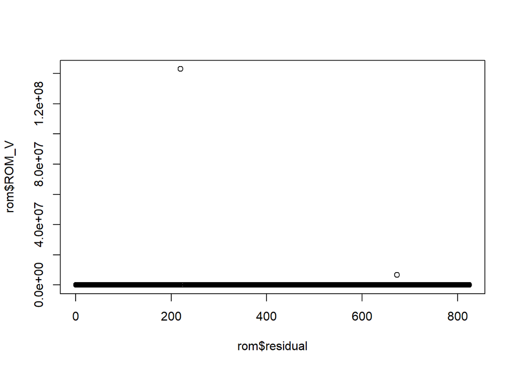

```r
rom <- mutate(rom, residual = 1:n()) # Added a column for observations / residuals

plot(rom$residual, rom$ROM_V) # Observed outliers in ROM_V, deleted them for further analysis
```

```r
which(rom$ROM_V > 300) # To find unusually large ROM_V values
```

```
## [1] 163 220 673
```

```r
which(rom$ROM_V < 0.0001) # To find unusually small ROM_V values
```

```
## [1]   6  16  17 255 497 562 564
```

```r
rom1 <- rom[-c(163, 220, 673, 6, 16, 17, 255, 497, 562, 564),] # Made new variable with deleted outliers
```

Note: Upon inspecting the values within “ROM_V”, it was clear that there are many extreme outliers. The residuals with extremely high “ROM_V” values are: 163, 220 and 673. It is possible that the ratio between the mean and standard deviation values are quite disproportionate compared to the other observations, resulting in larger values.

Similarly, observations 6, 16, 17, 255, 497, 562 and 564 have “ROM_V” values in e-05. While assessing the relevant columns, it was found that the standard deviation values may be improperly labelled. Both “ctrl.sd” and “oa.sd” values ranges from 0.0001 to over 30,000. This is not characteristic to standard deviation because it explains the distance between a certain value with the mean. Thus, the standard deviation column is likely to be mislabeled, and should be representing standard error instead.

The outliers will be deleted for subsequent analysis.

Lastly, some “ROM” and “ROM_V” values are “NA”. This occurs when there is negative “oa.mean” values, but positive “ctrl.mean” values.

### 5. Correct meta-analytic model fitted to the data that controls for the sampling variance of lnRR. The model should include a random effect of study and observation. Use metafor’s rma.mv() function.

```r
MLMA <- metafor:: rma.mv(ROM ~ 1 , V = ROM_V,
                         method = "REML",
                         random=list(~1 | Study,
                                     ~1 | Species,
                                     ~1 | residual),
                         test = "t", dfs = "contain",
                         data = rom1)
```

### 6. Written paragraph of the findings and what they mean which is supported with a figure. The paragraph should include:

- Correct presentation and interpretation of overall meta-analytic mean and measures of uncertainty around the mean estimate (e.g., 95% confidence intervals).
- Measures of heterogeneity in effect size estimates across studies (i.e., I2 and/or prediction intervals - see predict() function in metafor)
- Forest plot showing the mean estimate, 95% confidence interval, and prediction interval with clearly labelled axes, number of samples and studies plotted on figure

```r
summary(MLMA) # To get intercept and 95% Confidence intervals
```

```
##
## Multivariate Meta-Analysis Model (k = 791; method: REML)
##
##     logLik    Deviance         AIC         BIC        AICc
## -1751.2036   3502.4072   3510.4072   3529.0953   3510.4581
##
## Variance Components:
##
##             estim    sqrt  nlvls  fixed    factor
## sigma^2.1  0.2520  0.5020     92     no     Study
## sigma^2.2  0.2252  0.4746     62     no   Species
## sigma^2.3  3.9467  1.9866    791     no  residual
##
## Test for Heterogeneity:
## Q(df = 790) = 73608.2171, p-val < .0001
##
## Model Results:
##
## estimate      se     tval  df    pval    ci.lb   ci.ub
##  -0.0629  0.1249  -0.5040  61  0.6161  -0.3127  0.1868
##
## ---
## Signif. codes:  0 '***' 0.001 '**' 0.01 '*' 0.05 '.' 0.1 ' ' 1
```

```r
pi_val <- predict(MLMA)
pi_val # To get 95% Prediction interval
```

```
##
##     pred     se   ci.lb  ci.ub   pi.lb  pi.ub
##  -0.0629 0.1249 -0.3127 0.1868 -4.2762 4.1503
```

```r
I2_val <-  orchaRd::i2_ml(MLMA)
I2_val # Shows dissection of variation in effects within and across studies
```

```
##    I2_Total    I2_Study  I2_Species I2_residual
##   99.888969    5.690480    5.085194   89.113295
```

```r
# Made a new multilevel meta-regression model to observe ROM against moderator "Climate..FishBase."
MLMR <-  metafor:: rma.mv(ROM ~ Climate..FishBase., V = ROM_V,
                          method = "REML",
                          random=list(~1 | Study,
                                      ~1 | Species,
                                      ~1 | residual),
                          test = "t", dfs = "contain",
                          data = rom1)
```

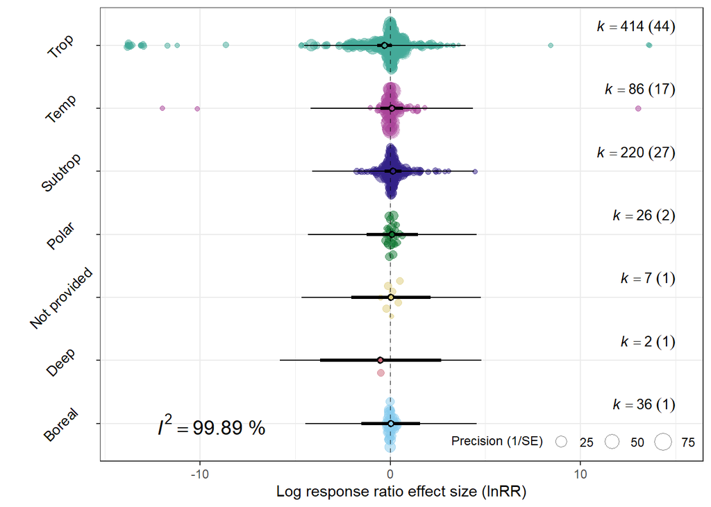

Figure 1: Orchard plot with Log repsonse ratio (lnRR) as effect size for Ocean acidification and fish behaviour in relations to Climate conditions. k = Effect size, Number of studies in brackets, scaled to precision of each effect size value (1/ROM_V)

```r
orchaRd::orchard_plot(MLMR, mod = "Climate..FishBase.", group = "Study", data = rom, xlab = "Log response ratio effect size (lnRR)", angle = 45) +
  annotate(geom = "text", x = 1, y = -10,
           label = paste0("italic(I)^{2} == ",round(I2_val[1], 2)),
           color = "black", parse = TRUE, size = 5) +
  annotate(geom = "text", x = 0.95, y = -7, label = "%", color = "black", parse = FALSE, size = 5)
```

The resultant 95% confidence and prediction intervals are -0.3127 to 0.1868 and -4.2762 to 4.1503, respectively. While 95% of the time we can be confident the true mean would fall between LnRR values of -0.3127 to 0.1868, we also expect effect sizes to range from -4.2762 to 4.1503 with 95% of repeated experiments. Such a broad prediction interval is indicative of high inconsistency between studies.

Aside from prediction intervals, we can also deduce levels of heterogeneity through I2. I2 represents the allocation of variation from within and across studies into “Total” and the aforementioned random effects. Evidently, we observe complete heterogeneous effect size because sampling variance contributes 0.1% (100% - I(total)^2) of total variation in effect size. Likewise, we observe 5.69% of total effect size variation due to differences in studies, 5.08% due to differences in species, and 89.11% due to residual effects.

### 7. Funnel plot for visually assessing the possibility of publication bias.

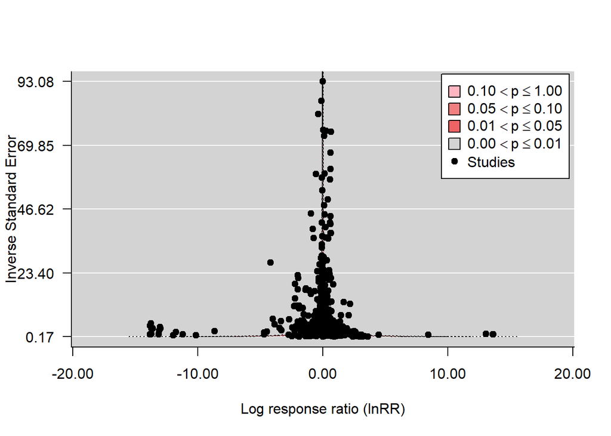

```r
metafor::funnel(x = rom1$ROM, vi = rom1$ROM_V,
                yaxis = "seinv", digits = 2,
                level = c(0.1, 0.05, 0.01),
                shade = c("lightpink", "lightcoral", "indianred2"), las = 1,
                xlab = "Log response ratio (lnRR)", legend = TRUE)
```

### 8. Time-lag plot assessing how effect sizes may or may not have changed through time

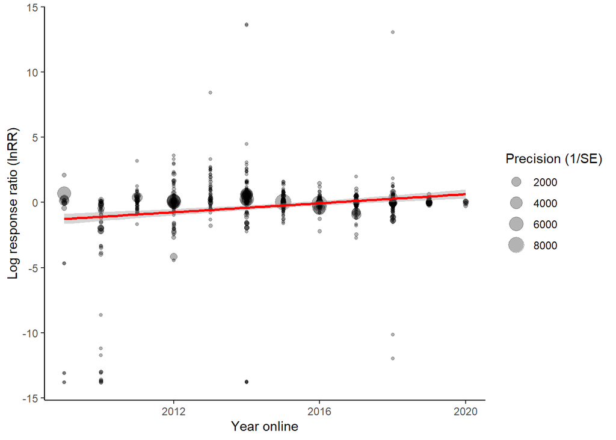

Figure 3: Time lag plot to assess Log response ratio against the year it became online. Point sizes are scaled depending on precision (1/ROM_V), with smaller points indicating lower precision and high sample variance.

```r
ggplot(rom1, aes(y = ROM, x = Year..online., size = 1/ROM_V)) + geom_point(alpha = 0.3) +
    geom_smooth(method = lm, col = "red", show.legend = FALSE) + labs(x = "Year online",
    y = "Log response ratio (lnRR)", size = "Precision (1/SE)") +
    theme_classic()
```

### 9. Formal meta-regression model that includes year as a moderator (fixed effect) to test for time-lag bias

```r
rom1 <- rom1 %>% mutate(Year_c = Year..online. - mean(Year..online.))
MLMR1 <-  metafor:: rma.mv(ROM ~ Year_c, V = ROM_V,
                          method = "REML",
                          random=list(~1 | Study,
                                      ~1 | Species,
                                      ~1 | residual),
                          test = "t", dfs = "contain",
                          data = rom1)
summary(MLMR1)
```

```
##
## Multivariate Meta-Analysis Model (k = 791; method: REML)
##
##     logLik    Deviance         AIC         BIC        AICc
## -1745.6063   3491.2126   3501.2126   3524.5664   3501.2892
##
## Variance Components:
##
##             estim    sqrt  nlvls  fixed    factor
## sigma^2.1  0.1775  0.4213     92     no     Study
## sigma^2.2  0.2196  0.4686     62     no   Species
## sigma^2.3  3.9549  1.9887    791     no  residual
##
## Test for Residual Heterogeneity:
## QE(df = 789) = 73168.4145, p-val < .0001
##
## Test of Moderators (coefficient 2):
## F(df1 = 1, df2 = 90) = 7.9701, p-val = 0.0059
##
## Model Results:
##
##          estimate      se     tval  df    pval    ci.lb   ci.ub
## intrcpt   -0.1131  0.1209  -0.9353  60  0.3534  -0.3549  0.1288
## Year_c     0.1115  0.0395   2.8231  90  0.0059   0.0330  0.1900  **
##
## ---
## Signif. codes:  0 '***' 0.001 '**' 0.01 '*' 0.05 '.' 0.1 ' ' 1
```

```r
r2_1 <- orchaRd::r2_ml(MLMR1)
r2_1
```

```
##    R2_marginal R2_conditional
##     0.02213319     0.11135919
```

### 10. Formal meta-regression model that includes inverse sampling var (i.e., 1vlnRR) to test for file-drawer biases

```r
rom1 <- rom1 %>% mutate(inv_lnRR = 1/(ROM_V))
MLMR2 <-  metafor:: rma.mv(ROM ~ Year_c + inv_lnRR, V = ROM_V,
                          method = "REML",
                          random=list(~1 | Study,
                                      ~1 | Species,
                                      ~1 | residual),
                          test = "t", dfs = "contain",
                          data = rom1)
summary(MLMR2)
```

```
##
## Multivariate Meta-Analysis Model (k = 791; method: REML)
##
##     logLik    Deviance         AIC         BIC        AICc
## -1742.4016   3484.8031   3496.8031   3524.8201   3496.9107
##
## Variance Components:
##
##             estim    sqrt  nlvls  fixed    factor
## sigma^2.1  0.1696  0.4119     92     no     Study
## sigma^2.2  0.2271  0.4765     62     no   Species
## sigma^2.3  3.9453  1.9863    791     no  residual
##
## Test for Residual Heterogeneity:
## QE(df = 788) = 72594.0625, p-val < .0001
##
## Test of Moderators (coefficients 2:3):
## F(df1 = 2, df2 = 89) = 5.5763, p-val = 0.0052
##
## Model Results:
##
##           estimate      se     tval   df    pval    ci.lb   ci.ub
## intrcpt    -0.1648  0.1247  -1.3218   59  0.1913  -0.4143  0.0847
## Year_c      0.1172  0.0395   2.9704   89  0.0038   0.0388  0.1956  **
## inv_lnRR    0.0002  0.0001   1.7348  788  0.0832  -0.0000  0.0004   .
##
## ---
## Signif. codes:  0 '***' 0.001 '**' 0.01 '*' 0.05 '.' 0.1 ' ' 1
```

```r
r2_2 <- orchaRd::r2_ml(MLMR2)
r2_2
```

```
##    R2_marginal R2_conditional
##     0.02737936     0.11624654
```

### 11. A written paragraph that discusses the potential for publication bias based on the meta-regression results. What type of publication bias, if any, appears to be present in the data? If publication bias is present, what does it mean and what might be contributing to such bias?

Overall, there is limited presence of publication biases shown in the meta-regression results.

Firstly, Funnel plots helps to expose presence of publication bias within the dataset. As seen in figure 2, there are more studies with lower precision (1/SE) on the negative end of the lnRR spectrum, while the number of higher lnRR values increase as precision increases. This display can be indicative of no file-drawer bias present, as we would expect studies with low precision to be stashed away, hence would observe less studies with negative lnRR with low precision.

Lastly, MLMR2 conceptualises the presence of both time-lag and file-drawer bias due to moderators being both year online and inverse of lnRR variance. The “R2_marginal” for MLMR2 is 0.027, indicating that both file-drawer and time-lag accounts for 2.74% of variation in lnRR.

### 12. Identify any studies contributing to publication bias. How do your updated meta-analysis results compare with a meta-analysis by Clement et. al. (2022)? Are there any concerns about these studies? If so, describe using references to existing papers what concerns have been raised?

Clement et al., explored the presence of decline effect (decreased effect size over time) through dissection of multiple biases that may be prevalent in Ocean acidification and behavioural studies. Particularly, they assessed evidence for publication bias (Strong effect studies tends to be more readily published in higher-impact journals), citation bias (Those in higher-impact journals tends to be cited more, thus have stronger influence), methodological bias (Chosen experimental design or sample size inflates the effect size) and investigator effect (subsequent papers from same author decreases effect size).

Figure 1 of their report noted the presence of decline effect. Both a and b explained the relationship between lnRR magnitude in accordance to year online. The 95% confident LOWESS curve in figure 1a exhibited higher lnRR magnitude during the first year, and had a sharp decline until 2012. Similarly, 2019 studies in figure 1b exhibited the largest 95% confidence bounds, displaying a large uncertainty. Thus, they confirmed the presence of decline effect.

Although they hypothesized that the presence of decline effect stemmed from the aforementioned biases and effects, they still investigated other factors that could inflate effect size. Such factors include mechanistic differences of warm and cold water fish species, isolation of olfactory cues, and sampling of only larvae. While they found no significant effect in the factors, they noted discrepancies in the methodology due to no actual background CO2 levels reported. However, the lack of signal indicated that the decline effect could be present due to the biases.

Publication and citation bias can be categorised into one group, as publication bias tends to fuel citation bias. When assessing the proportion of effect size magnitude with journal impact factor and Google Scholar citations, they noted that the first 3 studies has much higher citation rates than others, including one from 2012. This leads to unparallel influences from those studies, thus misleads the general public. Those papers are: Munday et al (2009), Dixson et al (2009), Munday et al (2010), and Nilsson et al (2012).

They also assessed the presence of Methodological bias, which was done by correlating the mean sample size of studies with the mean effect size magnitude. They concluded that studies with high lnRR tends to have low sample size (less than 3 fishes). This can have confounding effects as low sample size correlates to lower quality since it becomes more prone to statistical errors such as Type 1 and Type 2 errors. In the supplementary 1 information, these studies are: a2, a3 and a31, and they had sample sizes of 45, 18 and 11, respectively. In supplementary 5, these studies are Dixon et al (2009), Munday et al (2010), and Munday et al (2014).

The analysis of investigator effect involved removing early studies with similar lead investigators. In total, they removed 45% of those studies, most of which were studies before 2012, and revealed that the decline effect was no longer visible. Thus, they concluded the contribution of investigator effect onto decline effect.

The discrepancy between the updated meta-analyses and the findings from Clement et al can relate to the deletion of outliers early on. Due to the extremities of some lnRR variance, it involved the deletion of 10 observations, including Munday et al (2009), Dixson et al (2009), and Munday et al (2012). This already lowers the effects of investigator, methodological, and both publication and citation bias. As such, we are left with low levels of biases, with time-lag explaining 2.21% of variation in lnRR across studies, and both file-drawer and time-lag explaining 2.74%.

Reproducibility (30%): 1. Code, analysis and data is setup in a public GitHub Repository 2. Workflow, meta-data and file structure is clearly documented (using a README file) as is the history of changes for each file. 3. Rmarkdown documents follow reproducibility principles: + Rmarkdown document rendered as an html! + Use Figure and Table code chunks that are referenced in text. + Writing of findings is done using inline code chunks with reference to specific object values.

Coding, Writing Structure & Presentation (20%): 1. Code is clearly annotated, clean, and only what is needed is presented 2. Figure and Tables have clear and well labelled captions that are informative and correctly referenced within the document. 3. Sentences are clear and understandable.